# Long/Short Overlay Portfolio: Methodology & Results

2026-03-15

## 1. Overview

This document describes a **standalone Long/Short (L/S) Momentum Overlay** built on top of a 59-ETF relative-return universe. The strategy is dollar-neutral: the long leg and short leg each carry ±100% notional, so net market exposure is zero. All returns are expressed as **relative returns vs SPY** (`xts_rel`), meaning:

- A long position earns when the ETF outperforms SPY
- A short position earns when the ETF underperforms SPY
- The portfolio P&L is **pure cross-sectional alpha** — market direction cancels out

## 2. Data: Relative Returns (`xts_rel`)

`xts_rel` is produced by `scripts/01_etf_wrangle.R`. Each column is the arithmetic daily return spread of one ETF vs SPY:

$$r^{rel}_{i,t} = r^{ETF}_{i,t} -
r^{SPY}_t$$

The SPY column itself is identically zero. All other tickers represent a **Long ETF / Short SPY** position. This is the raw material for the overlay.

```
## Universe : 60 tickers
```

```
## Period   : 2018-01-03 to 2026-03-13
```

```
## Obs      : 2114 trading days
```

## 3. Portfolio Construction

### 3.1 Signal

At each monthly rebalance date, compute the **cumulative relative return** of every ETF over the prior `signal_lookback` trading days (default: 63 days = 1 quarter):

$$\text{signal}_i = \prod_{t-L}^{t}(1 +
r^{rel}_{i,t}) - 1$$

This is a cross-sectional momentum signal in relative-return space: ETFs that have been beating SPY the most over the past quarter are expected to continue doing so.

### 3.2 Weight Assignment

Rank all ETFs by signal (descending). Assign:

- **Long**: top `n_long` ETFs → weight $w_i = +\frac{1}{n_{long}}$
- **Short**: bottom `n_short` ETFs → weight $w_i = -\frac{1}{n_{short}}$
- **Neutral**: all others → weight $0$

By construction: $\sum_i w_i = +1 - 1 = 0$ (dollar neutral).

### 3.3 Return Computation

Each day the portfolio return is the inner product of current weights and relative returns:

$$R^{port}_t = \sum_i w_i \cdot
r^{rel}_{i,t}$$

> **Why not `Return.portfolio()`?** PerformanceAnalytics normalises by total portfolio value: $\frac{\sum w_i R_i}{\sum w_i}$. For a dollar-neutral book $\sum w_i = 0$, this produces $0/0$ — silently collapsed to zero for the entire history. Weights are instead broadcast to a daily matrix and returns computed directly via `rowSums(w_daily * xts_u)`.

### 3.4 Implementation

```r
build_ls_portfolio <- function(xts_rel,
                                n_long           = 5L,
                                n_short          = 5L,
                                signal_lookback  = 63L,
                                rebalance_freq   = "months",
                                min_hold_days    = 0L,
                                universe_tickers = NULL) {

  valid_freqs <- c("months", "quarters", "years")
  if (!(rebalance_freq %in% valid_freqs))
    stop("rebalance_freq must be one of: months, quarters, years")
  if (min_hold_days < 0L) stop("min_hold_days must be >= 0")
  if (n_long < 1 || n_short < 1) stop("n_long and n_short must be >= 1")

  # Universe
  if (!is.null(universe_tickers)) {
    universe_tickers <- intersect(universe_tickers, colnames(xts_rel))
  } else {
    universe_tickers <- setdiff(colnames(xts_rel), "SPY")
  }
  n_universe <- length(universe_tickers)
  xts_u      <- xts_rel[, universe_tickers]

  if (n_universe < n_long + n_short)
    stop(sprintf("Universe has %d tickers but n_long + n_short = %d.",
                 n_universe, n_long + n_short))

  # Rebalance endpoints
  ep <- endpoints(xts_u, on = rebalance_freq)
  ep <- ep[ep > 0]

  rebal_dates <- index(xts_u)[ep]
  w_mat <- matrix(NA_real_, nrow = length(ep), ncol = n_universe,
                  dimnames = list(as.character(rebal_dates), universe_tickers))

  signal_history <- list()
  last_rebal_idx <- NA_integer_

  for (k in seq_along(ep)) {
    ep_i <- ep[k]

    # Minimum holding period guard
    if (min_hold_days > 0L && !is.na(last_rebal_idx)) {
      if ((ep_i - last_rebal_idx) < min_hold_days) next
    }

    # Signal: cumulative return over lookback window
    lb_start <- max(1L, ep_i - signal_lookback + 1L)
    win      <- xts_u[lb_start:ep_i, ]
    cum_ret  <- vapply(universe_tickers, function(tk) {
      x <- as.numeric(win[, tk]); x <- x[!is.na(x)]
      if (length(x) == 0) return(NA_real_)
      prod(1 + x) - 1
    }, numeric(1))

    cum_valid <- cum_ret[!is.na(cum_ret)]
    if (length(cum_valid) < n_long + n_short) next

    ranked      <- sort(cum_valid, decreasing = TRUE)
    long_names  <- names(ranked)[seq_len(n_long)]
    short_names <- names(ranked)[seq(length(ranked) - n_short + 1L, length(ranked))]

    w_row <- setNames(rep(0, n_universe), universe_tickers)
    w_row[long_names]  <-  1 / n_long
    w_row[short_names] <- -1 / n_short
    w_mat[k, ]   <- w_row
    last_rebal_idx <- ep_i

    signal_history[[as.character(rebal_dates[k])]] <- data.frame(
      ticker = names(cum_valid), signal = as.numeric(cum_valid),
      rank   = rank(-cum_valid, ties.method = "first"),
      side   = ifelse(names(cum_valid) %in% long_names,  "Long",
               ifelse(names(cum_valid) %in% short_names, "Short", "Neutral")),
      stringsAsFactors = FALSE
    )
  }

  # Drop unassigned rows
  valid_rows  <- !is.na(w_mat[, 1])
  w_mat       <- w_mat[valid_rows, , drop = FALSE]
  rebal_dates <- rebal_dates[valid_rows]
  w_xts       <- xts(w_mat, order.by = rebal_dates)

  # Broadcast weights to daily and compute returns arithmetically
  all_dates <- index(xts_u)
  w_daily   <- matrix(NA_real_, nrow = length(all_dates), ncol = n_universe,
                      dimnames = list(NULL, universe_tickers))

  for (k in seq_len(nrow(w_mat))) {
    period_start <- rebal_dates[k]
    period_end   <- if (k < nrow(w_mat)) rebal_dates[k + 1L] else tail(all_dates, 1L)
    day_idx      <- which(all_dates >= period_start & all_dates <= period_end)
    if (length(day_idx) > 0)
      w_daily[day_idx, ] <- matrix(rep(w_mat[k, ], length(day_idx)),
                                   nrow = length(day_idx), byrow = TRUE)
  }

  w_daily_xts <- xts(w_daily, order.by = all_dates)
  first_idx   <- which(all_dates >= rebal_dates[1L])[1L]
  if (first_idx > 1L) w_daily_xts[seq_len(first_idx - 1L), ] <- NA

  port_ret_vec        <- rowSums(w_daily_xts * xts_u, na.rm = FALSE)
  port_ret_xts        <- xts(port_ret_vec, order.by = all_dates)
  port_ret_xts        <- port_ret_xts[!is.na(port_ret_xts)]
  colnames(port_ret_xts) <- "LS_Overlay"

  list(
    returns        = port_ret_xts,
    weights_bop    = w_daily_xts,
    weights_rebal  = w_xts,
    signal_history = signal_history
  )
}
```

## 4. Universe Selection: Eigenvector Analysis

### 4.1 Motivation

Running the overlay on all 59 ETFs inflates the Sharpe ratio through **breadth redundancy**: many tickers load on the same underlying factor, so the portfolio is implicitly concentrating in a handful of risk premia while appearing diversified. PCA on `xts_rel` reveals the true factor structure.

### 4.2 PCA on the Relative-Return Correlation Matrix

```r
xts_u_full <- xts_rel[, setdiff(colnames(xts_rel), "SPY")]
xts_u_full <- xts_u_full[, apply(xts_u_full, 2, function(x) sd(x, na.rm = TRUE) > 0)]

pca <- prcomp(as.matrix(xts_u_full), scale. = TRUE, center = TRUE)

var_exp <- summary(pca)$importance[2, 1:8]
cum_var <- summary(pca)$importance[3, 1:8]
```

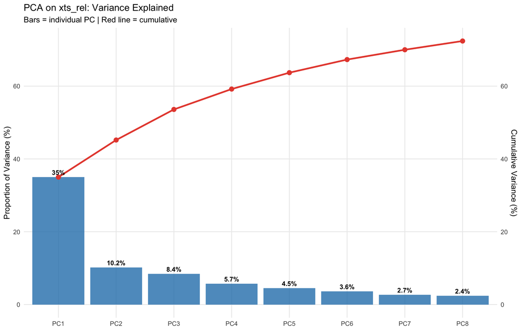

### 4.3 Factor Interpretation

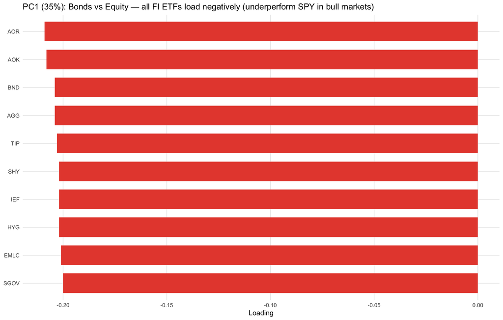

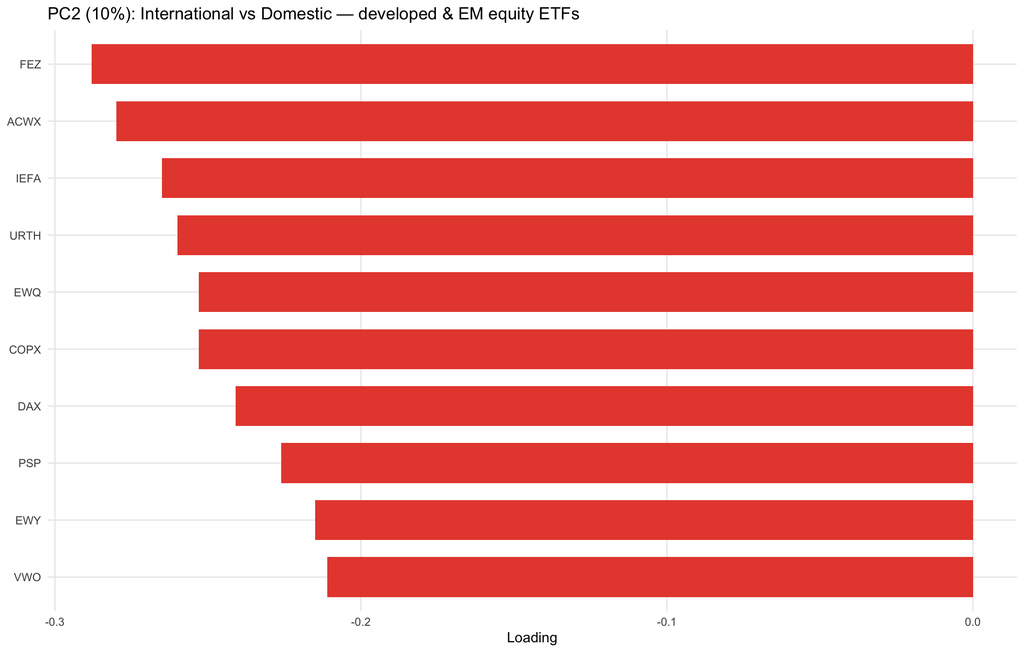

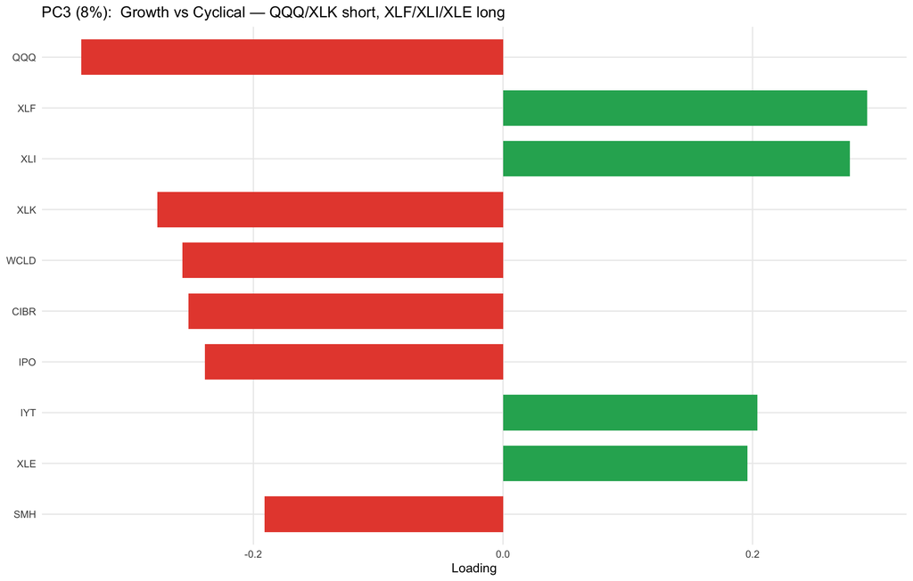

### 4.4 Eigenvector Centrality

The leading eigenvector of the correlation matrix (which is identical to PC1 loadings) measures how “connected” each ETF is to the rest of the network. High centrality = the ETF moves with many others simultaneously.

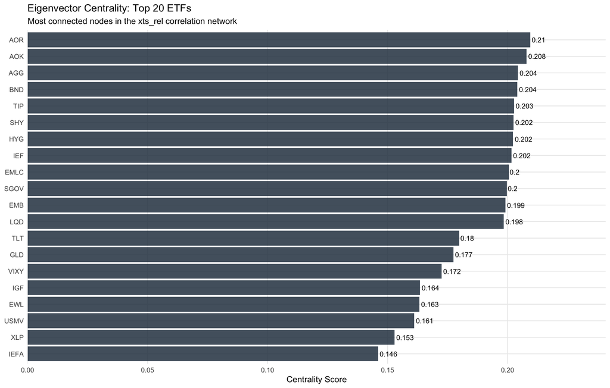

### 4.5 Restricted Core Universe (15 ETFs)

After removing redundant pairs (AGG ≈ BND, SHY ≈ SGOV, IEFA ≈ ACWX ≈ URTH, dropping composite balanced funds AOR/AOK), the **15-ETF core universe** covers all three principal factors:

| Factor | ETFs |
| --- | --- |
| PC1 — Rates / Bonds | `AGG`, `IEF`, `TLT`, `HYG`, `TIP` |
| PC2 — International | `IEFA`, `FEZ`, `VWO` |
| PC3 — Equity Rotation | `QQQ`, `XLK`, `XLF`, `XLI`, `XLE` |
| Tail / Regime | `GLD`, `VIXY` |

## 5. Results

### 5.1 Build Both Portfolios

```r
# Full 59-ticker universe
ls_full <- build_ls_portfolio(
  xts_rel         = xts_rel,
  n_long          = 5L,
  n_short         = 5L,
  signal_lookback = 63L,
  rebalance_freq  = "months"
)

# Restricted 15-ETF core universe
core_universe <- c(
  "AGG", "IEF", "TLT", "HYG", "TIP",
  "IEFA", "FEZ", "VWO",
  "QQQ", "XLK", "XLF", "XLI", "XLE",
  "GLD", "VIXY"
)

ls_core <- build_ls_portfolio(
  xts_rel          = xts_rel,
  n_long           = 5L,
  n_short          = 5L,
  signal_lookback  = 63L,
  rebalance_freq   = "months",
  universe_tickers = core_universe
)

# Align and merge
common_idx <- intersect(index(ls_full$returns), index(ls_core$returns))
comp <- merge(ls_full$returns[common_idx], ls_core$returns[common_idx])
colnames(comp) <- c("LS_Full_59", "LS_Core_15")
```

### 5.2 Weight History — Core Universe

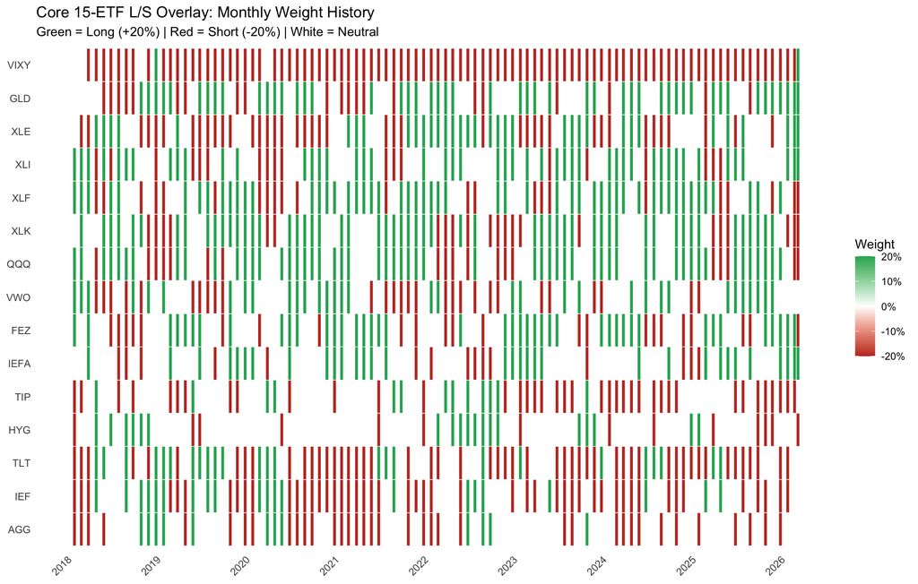

### 5.3 Annualized Performance

Annualized Performance: Full vs Core Universe

[output not shown]

### 5.4 Performance Summary Chart

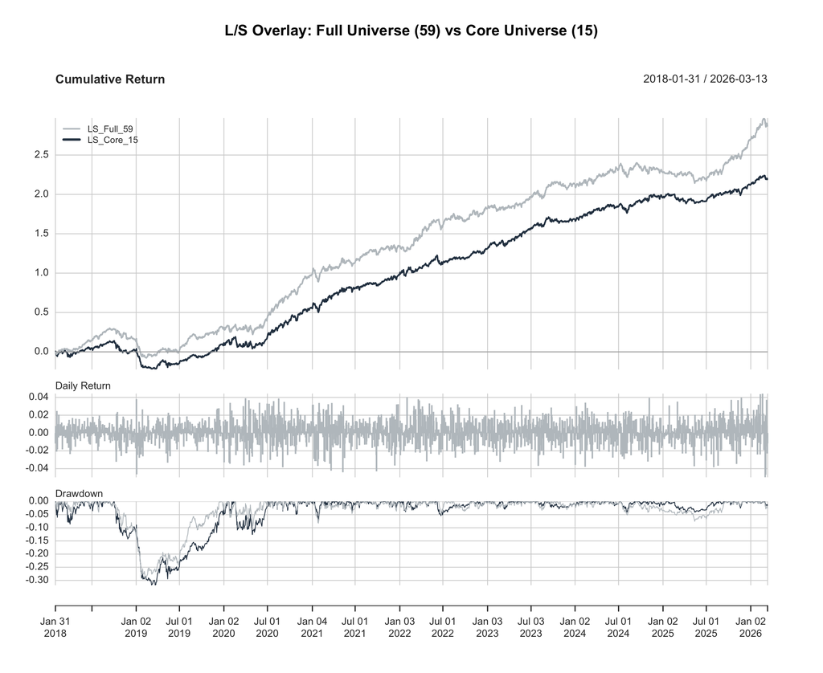

### 5.5 Drawdown Analysis

```
## Full Universe (59 ETFs) — Top 5 Drawdowns
```

[output not shown]

```
##
## Core Universe (15 ETFs) — Top 5 Drawdowns
```

```
##         From     Trough         To   Depth Length To Trough Recovery
## 1 2018-10-04 2019-03-07 2020-02-06 -0.3109    346       109      237
## 2 2020-02-20 2020-04-30 2020-07-02 -0.1467     95        50       45
## 3 2025-01-24 2025-04-08 2025-08-28 -0.1217    154        53      101
## 4 2022-06-08 2022-06-23 2022-10-27 -0.1157    102        12       90
## 5 2021-01-11 2021-01-29 2021-02-12 -0.1135     25        15       10
```

## 6. Key Findings

Summary Comparison

[output not shown]

## 7. Phase 2: L/S Overlay on a 50/50 Core Portfolio

### 7.1 Motivation

The L/S overlay is dollar-neutral (net weight = 0), so bolting it onto any long-only core portfolio leaves market exposure **unchanged**. The combined return is simply:

$$R^{combined}_t = R^{core}_t +
R^{LS}_t$$

This section tests whether the overlay improves the risk-adjusted profile of a simple **50% SPY / 50% AGG** benchmark, rebalanced monthly.

```r
library(here)

# Load absolute returns (needed for calc_saa_portfolio)
xts_ret <- readRDS(here("02_data_processed/xts_ret_returns.rds"))

# Load SAA engine
source(here("scripts_saa_taa/05_saa_portfolio.R"))

# Build 50/50 core
core_5050 <- calc_saa_portfolio(
  xts_returns    = xts_ret,
  weights_vector = c(SPY = 0.50, AGG = 0.50),
  rebalance_freq = "months"
)

# Align all three series to common dates
common_idx2  <- intersect(index(core_5050$returns), index(ls_core$returns))
core_ret     <- core_5050$returns[common_idx2]
ls_ret       <- ls_core$returns[common_idx2]
combined_ret <- xts(as.numeric(core_ret) + as.numeric(ls_ret), order.by = common_idx2)

colnames(core_ret)     <- "Core_5050"
colnames(ls_ret)       <- "LS_Core_15"
colnames(combined_ret) <- "Core_plus_LS"

phase2_comp <- merge(core_ret, ls_ret, combined_ret)
```

### 7.2 Annualized Performance

Phase 2: Core (50/50) vs L/S Overlay vs Combined

|  | Core_5050 | LS_Core_15 | Core_plus_LS |
| --- | --- | --- | --- |
| Annualized Return | 0.0922 | 0.2820 | 0.3910 |
| Annualized Std Dev | 0.0875 | 0.1767 | 0.2277 |
| Annualized Sharpe (Rf=0%) | 1.0547 | 1.5963 | 1.7170 |

### 7.3 Top Drawdowns — Core + L/S Combined

Core + L/S: Top 5 Drawdowns

| From | Trough | To | Depth | Length | To Trough | Recovery |
| --- | --- | --- | --- | --- | --- | --- |
| 2018-10-02 | 2019-01-25 | 2019-11-28 | -0.3218 | 300 | 82 | 218 |
| 2020-02-20 | 2020-03-18 | 2020-07-02 | -0.2212 | 95 | 20 | 75 |
| 2025-02-20 | 2025-04-08 | 2025-07-23 | -0.1817 | 109 | 34 | 75 |
| 2022-06-08 | 2022-06-23 | 2022-08-18 | -0.1651 | 52 | 12 | 40 |
| 2024-07-11 | 2024-08-05 | 2024-09-03 | -0.1378 | 39 | 18 | 21 |

### 7.4 Wealth Index — Core / L/S / Combined

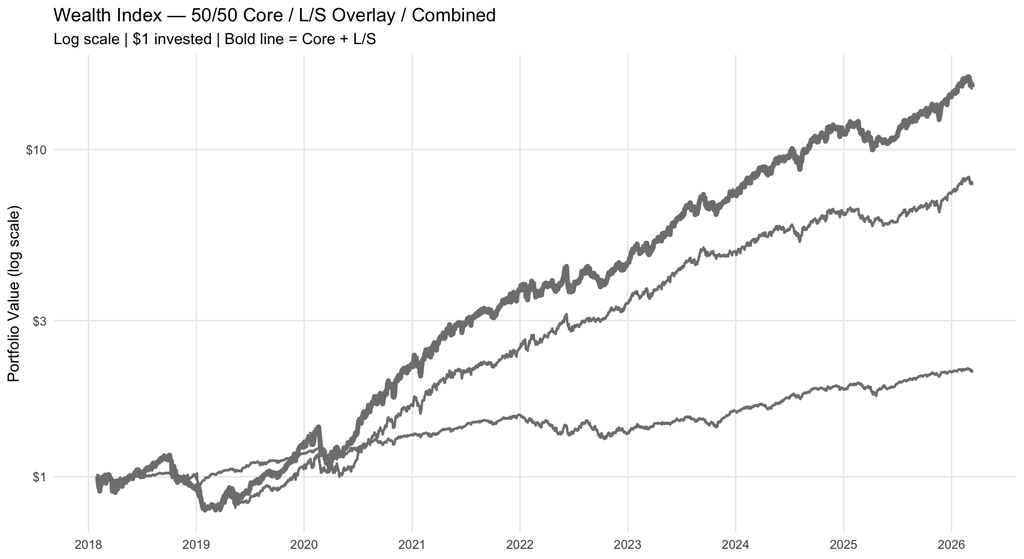

### 7.5 Daily Return Scatter — Core vs L/S

[figure not shown]

### 7.6 Rolling 252-Day Correlation — Core vs L/S

[figure not shown]

### 7.7 Annual Returns — Core / L/S / Combined

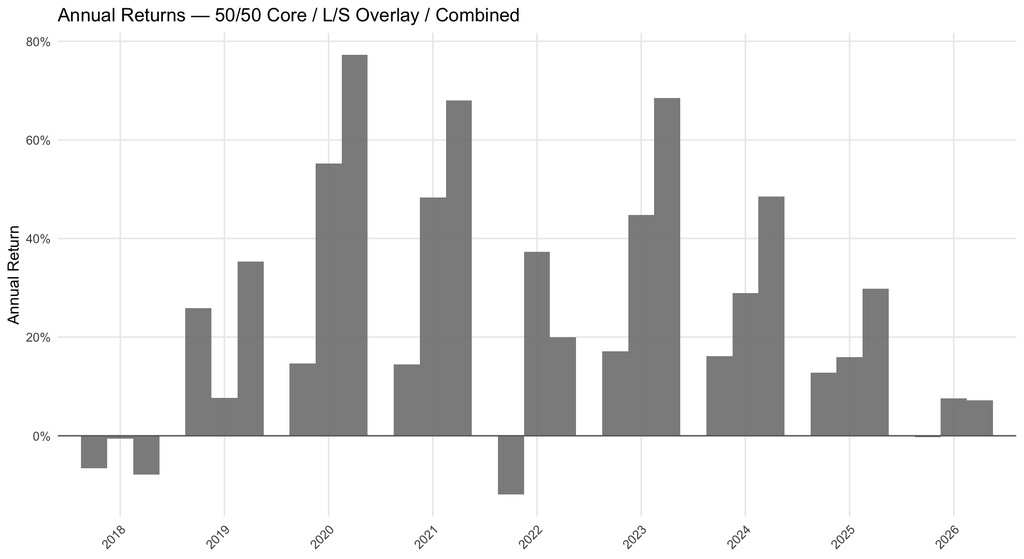

### 7.8 Drawdown Comparison

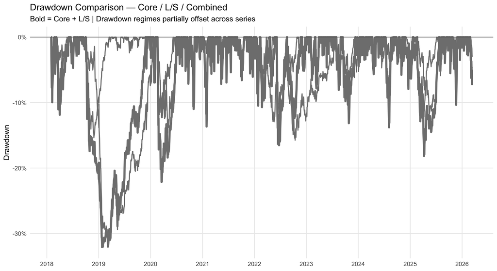

### 7.9 Risk/Return Space — All Portfolios

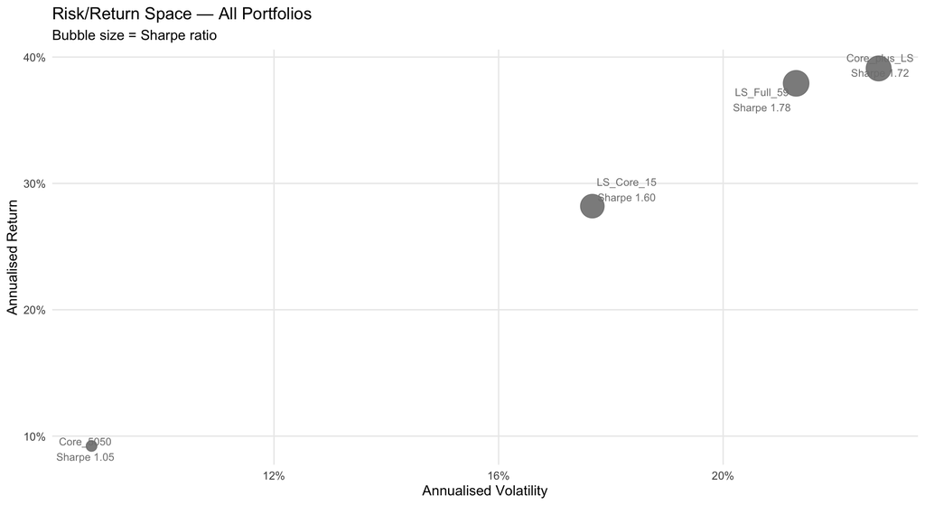

## 8. Key Findings — Phase 2

```
## Core 50/50        : Return 9.2% | Vol 8.7% | Sharpe 1.05
```

```
## Core + L/S Overlay: Return 39.1% | Vol 22.8% | Sharpe 1.72
```

```
## Sharpe improvement: +0.67
```

## 9. Next Steps

- **Robustness**: Sub-period stability (pre/post-COVID), sensitivity to `signal_lookback` (21d, 63d, 126d)
- **Transaction costs**: Estimate turnover-adjusted returns (monthly rebalancing on 15 ETFs)
- **Regime conditioning**: Gate the overlay on SPY regime state (run only in Consolidation, reduce exposure in Fall)
- **Extend universe**: Apply PCA-filtered selection to the full 59-ETF universe for robustness check

*Generated: 2026-03-15 | Data: 2018-01-01 to present | Signal: 63-day momentum on xts_rel*